# Modeling with Regression

Kobbe Harwell

```r
library(ggplot2)
library(PASWR2)
library(car)
library(dplyr)
library(lattice)
library(boot)
library(MASS)
```

## Data and idea comes from (*Militino et al., 2004*).

The goal is to create a multiple linear regression model that can be used to predict the total price of apartments by their structural characteristics. The data frame `VIT2005` contains several variables, and further description of the data can be found below.

- `totalprice` (the market total price (in Euros) of the apartment including garage(s) and storage room(s))
- `area` (the total living area of the apartment in square meters)
- `zone` (a factor indicating the neighborhood where the apartment is located with levels `Z11, Z21, Z31, Z32, Z34, Z35, Z36, Z37, Z38, Z41, Z42, Z43, Z44, Z45, Z46, Z47, Z48, Z49, Z52, Z53, Z56, Z61, and Z62`)
- `category` (a factor indicating the condition of the apartment with levels `2A, 2B, 3A, 3B, 4A, 4B`, and `5A` ordered so that `2A` is the best and `5A` is the worst)
- `age` (age of the apartment in years)
- `floor` (floor on which the apartment is located)
- `rooms` (total number of rooms including bedrooms, dining room, and kitchen)
- `out` (a factor indicating the percent of the apartment exposed to the elements: The levels `E100, E75, E50, and E25`, correspond to complete exposure, `75`% exposure, `50`% exposure, and `25`% exposure, respectively.)
- `conservation` (is an ordered factor indicating the state of conservation of the apartment. The levels `1A, 2A, 2B, and 3A` are ordered from best to worst conservation.)
- `toilets` (the number of bathrooms)
- `garage` (the number of garages)
- `elevator` (indicates the absence (0) or presence (1) of elevators.)
- `streetcategory` (an ordered factor from best to worst indicating the category of the street with levels `S2, S3, S4, and S5`)
- `heating` (a factor indicating the type of heating with levels `1A, 3A, 3B, and 4A` which correspond to: no heating, low-standard private heating, high-standard private heating, and central heating, respectively.)
- `storage` (the number of storage rooms outside of the apartment)
1. Characterize the shape, center, and spread of the variable `totalprice`.

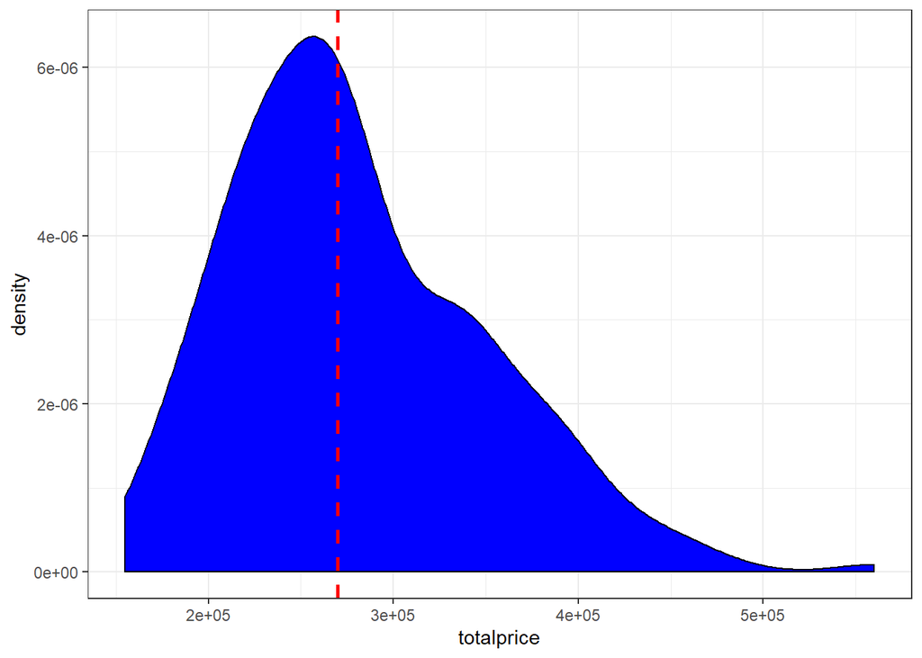

```r
ggplot(data = VIT2005, aes(x=totalprice)) + geom_density(fill="blue")+theme_bw()+geom_vline(aes(xintercept=median(totalprice)),color="red",linetype="dashed",size=1)
```

```r
MD <- median(VIT2005$totalprice)
#
iqr <- IQR(VIT2005$totalprice)
#
c(MD, iqr)
```

```
## [1] 269750 100125
```

**Observation:** The distribution of `totalprice` is skewed right with a median of `269750` and an `IQR` of `100125`

2. Explore the relationships between totalprice and the numerical explanatory variables `area, age, floor, rooms, toilets, garage, elevator`, and `storage`.

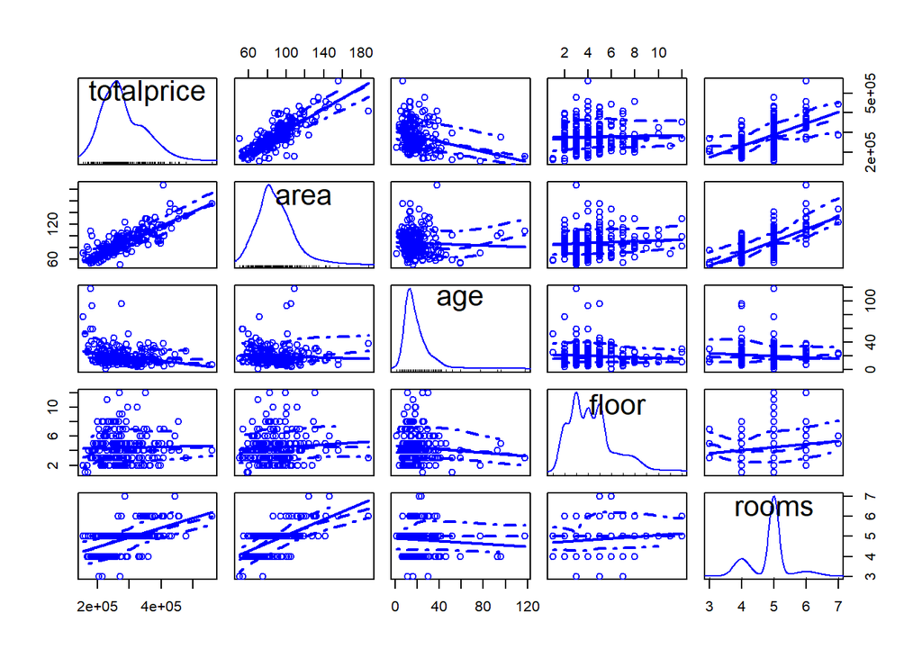

```r
scatterplotMatrix( ~ totalprice + area + age + floor + rooms, data = VIT2005)
```

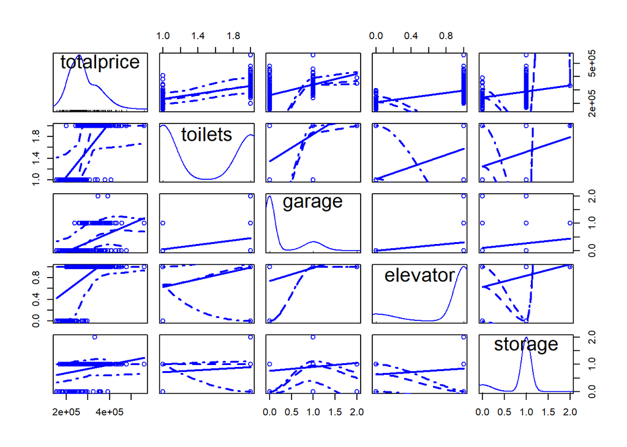

```r
scatterplotMatrix( ~ totalprice + toilets+ garage+ elevator+ storage, data = VIT2005)
```

The correlation coefficients are:

```r
NUM <- c("area", "age", "floor", "rooms", "toilets", "garage","elevator", "storage")
COR <- cor(VIT2005[, "totalprice"], VIT2005[, NUM])
COR
```

```
##           area        age      floor    rooms   toilets    garage  elevator
## [1,] 0.8092125 -0.2724497 0.02921993 0.525627 0.6875706 0.5237425 0.5109393
##        storage
## [1,] 0.2673579
```

**Observation:** The highest three correlations with `totalprice` occur with `area` (0.8092), `toilets` (0.6876), and `rooms`(0.5256).

**Model (A)** Backward elimination to develop a model that predicts totalprice using the data frame `VIT2005`. “P-value-to remove” of `5`%.

```r
model.be <- lm(totalprice ~ ., data = VIT2005)

drop1(model.be, test = "F")
```

```
## Single term deletions
##
## Model:
## totalprice ~ area + zone + category + age + floor + rooms + out +
##     conservation + toilets + garage + elevator + streetcategory +
##     heating + storage
##                Df  Sum of Sq        RSS    AIC F value    Pr(>F)
## <none>                       8.5891e+10 4412.6
## area            1 4.4519e+10 1.3041e+11 4501.7 87.5972 < 2.2e-16 ***
## zone           22 1.1171e+11 1.9760e+11 4550.3  9.9910 < 2.2e-16 ***
## category        6 9.5199e+09 9.5411e+10 4423.5  3.1219  0.006303 **
## age             1 3.7563e+06 8.5895e+10 4410.6  0.0074  0.931591
## floor           1 3.8440e+07 8.5929e+10 4410.7  0.0756  0.783639
## rooms           1 1.0656e+09 8.6956e+10 4413.3  2.0967  0.149472
## out             3 3.8946e+09 8.9785e+10 4416.3  2.5544  0.057135 .
## conservation    3 1.0031e+09 8.6894e+10 4409.2  0.6579  0.579069
## toilets         1 4.7971e+09 9.0688e+10 4422.5  9.4389  0.002477 **
## garage          1 1.4771e+10 1.0066e+11 4445.2 29.0627 2.328e-07 ***
## elevator        1 5.4265e+09 9.1317e+10 4424.0 10.6772  0.001314 **
## streetcategory  3 3.5550e+09 8.9446e+10 4415.5  2.3316  0.076019 .
## heating         3 4.3202e+09 9.0211e+10 4417.3  2.8335  0.039877 *
## storage         1 1.6433e+09 8.7534e+10 4414.8  3.2334  0.073937 .
## ---
## Signif. codes:  0 '***' 0.001 '**' 0.01 '*' 0.05 '.' 0.1 ' ' 1
```

Drop most insignificant variable from the model.

```r
model.be <- update(model.be, .~. - age)
drop1(model.be, test = "F")
```

```
## Single term deletions
##
## Model:
## totalprice ~ area + zone + category + floor + rooms + out + conservation +
##     toilets + garage + elevator + streetcategory + heating +
##     storage
##                Df  Sum of Sq        RSS    AIC F value    Pr(>F)
## <none>                       8.5895e+10 4410.6
## area            1 4.4894e+10 1.3079e+11 4500.3 88.8523 < 2.2e-16 ***
## zone           22 1.1220e+11 1.9810e+11 4548.8 10.0942 < 2.2e-16 ***
## category        6 9.6605e+09 9.5555e+10 4421.9  3.1866 0.0054598 **
## floor           1 3.6864e+07 8.5931e+10 4408.7  0.0730 0.7874016
## rooms           1 1.0655e+09 8.6960e+10 4411.3  2.1088 0.1482969
## out             3 4.0439e+09 8.9938e+10 4414.7  2.6678 0.0493562 *
## conservation    3 1.3497e+09 8.7244e+10 4408.0  0.8905 0.4473466
## toilets         1 4.7993e+09 9.0694e+10 4420.5  9.4987 0.0023994 **
## garage          1 1.4767e+10 1.0066e+11 4443.2 29.2260 2.153e-07 ***
## elevator        1 5.6740e+09 9.1569e+10 4422.6 11.2298 0.0009919 ***
## streetcategory  3 3.5550e+09 8.9450e+10 4413.5  2.3453 0.0746761 .
## heating         3 4.3716e+09 9.0266e+10 4415.5  2.8840 0.0373395 *
## storage         1 1.6950e+09 8.7590e+10 4412.9  3.3547 0.0687625 .
## ---
## Signif. codes:  0 '***' 0.001 '**' 0.01 '*' 0.05 '.' 0.1 ' ' 1
```

Which one is to be dropped next?

Answer: floor

```r
model.be <- update(model.be, .~. - floor)
drop1(model.be, test = "F")
```

```
## Single term deletions
##
## Model:
## totalprice ~ area + zone + category + rooms + out + conservation +
##     toilets + garage + elevator + streetcategory + heating +
##     storage
##                Df  Sum of Sq        RSS    AIC F value    Pr(>F)
## <none>                       8.5931e+10 4408.7
## area            1 4.4857e+10 1.3079e+11 4498.3 89.2643 < 2.2e-16 ***
## zone           22 1.1713e+11 2.0306e+11 4552.2 10.5949 < 2.2e-16 ***
## category        6 9.8951e+09 9.5826e+10 4420.5  3.2818 0.0044204 **
## rooms           1 1.0703e+09 8.7002e+10 4409.4  2.1299 0.1462887
## out             3 4.0364e+09 8.9968e+10 4412.7  2.6774 0.0487312 *
## conservation    3 1.3563e+09 8.7288e+10 4406.1  0.8997 0.4426615
## toilets         1 4.8110e+09 9.0742e+10 4418.6  9.5738 0.0023062 **
## garage          1 1.4733e+10 1.0066e+11 4441.2 29.3185 2.054e-07 ***
## elevator        1 5.7376e+09 9.1669e+10 4420.8 11.4175 0.0009011 ***
## streetcategory  3 3.5188e+09 8.9450e+10 4411.5  2.3341 0.0757310 .
## heating         3 4.4146e+09 9.0346e+10 4413.6  2.9283 0.0352446 *
## storage         1 1.6588e+09 8.7590e+10 4410.9  3.3010 0.0709881 .
## ---
## Signif. codes:  0 '***' 0.001 '**' 0.01 '*' 0.05 '.' 0.1 ' ' 1
```

Which one is to be dropped next?

Answer: conservation

```r
model.be <- update(model.be, .~. - conservation)
drop1(model.be, test = "F")
```

```
## Single term deletions
##
## Model:
## totalprice ~ area + zone + category + rooms + out + toilets +
##     garage + elevator + streetcategory + heating + storage
##                Df  Sum of Sq        RSS    AIC F value    Pr(>F)
## <none>                       8.7288e+10 4406.1
## area            1 4.4067e+10 1.3135e+11 4493.2 87.8431 < 2.2e-16 ***
## zone           22 1.1785e+11 2.0514e+11 4548.4 10.6787 < 2.2e-16 ***
## category        6 1.2678e+10 9.9966e+10 4423.7  4.2122 0.0005529 ***
## rooms           1 1.0246e+09 8.8312e+10 4406.7  2.0425 0.1547526
## out             3 4.5287e+09 9.1816e+10 4411.2  3.0092 0.0316923 *
## toilets         1 5.1432e+09 9.2431e+10 4416.6 10.2525 0.0016231 **
## garage          1 1.5621e+10 1.0291e+11 4440.0 31.1392  9.06e-08 ***
## elevator        1 5.7882e+09 9.3076e+10 4418.1 11.5382 0.0008449 ***
## streetcategory  3 3.5484e+09 9.0836e+10 4408.8  2.3578 0.0734020 .
## heating         3 3.9987e+09 9.1286e+10 4409.9  2.6570 0.0499673 *
## storage         1 1.6695e+09 8.8957e+10 4408.3  3.3280 0.0698262 .
## ---
## Signif. codes:  0 '***' 0.001 '**' 0.01 '*' 0.05 '.' 0.1 ' ' 1
```

Which one is to be dropped next?

Answer: rooms

```r
model.be <- update(model.be, .~. - rooms)
drop1(model.be, test = "F")
```

```
## Single term deletions
##
## Model:
## totalprice ~ area + zone + category + out + toilets + garage +
##     elevator + streetcategory + heating + storage
##                Df  Sum of Sq        RSS    AIC  F value    Pr(>F)
## <none>                       8.8312e+10 4406.7
## area            1 6.3300e+10 1.5161e+11 4522.5 125.4358 < 2.2e-16 ***
## zone           22 1.1695e+11 2.0526e+11 4546.5  10.5341 < 2.2e-16 ***
## category        6 1.2113e+10 1.0043e+11 4422.7   4.0004 0.0008860 ***
## out             3 4.8644e+09 9.3177e+10 4412.4   3.2131 0.0243109 *
## toilets         1 5.4584e+09 9.3771e+10 4417.8  10.8163 0.0012163 **
## garage          1 1.5751e+10 1.0406e+11 4440.5  31.2116 8.718e-08 ***
## elevator        1 6.3078e+09 9.4620e+10 4419.7  12.4996 0.0005209 ***
## streetcategory  3 3.3915e+09 9.1704e+10 4408.9   2.2402 0.0852905 .
## heating         3 4.1435e+09 9.2456e+10 4410.7   2.7369 0.0450560 *
## storage         1 1.5008e+09 8.9813e+10 4408.4   2.9740 0.0863783 .
## ---
## Signif. codes:  0 '***' 0.001 '**' 0.01 '*' 0.05 '.' 0.1 ' ' 1
```

Which one is to be dropped next?

Answer: storage

```r
model.be <- update(model.be, .~. - storage)
drop1(model.be, test = "F")
```

```
## Single term deletions
##
## Model:
## totalprice ~ area + zone + category + out + toilets + garage +
##     elevator + streetcategory + heating
##                Df  Sum of Sq        RSS    AIC  F value    Pr(>F)
## <none>                       8.9813e+10 4408.4
## area            1 6.4458e+10 1.5427e+11 4524.3 126.3141 < 2.2e-16 ***
## zone           22 1.1977e+11 2.0959e+11 4549.1  10.6688 < 2.2e-16 ***
## category        6 1.1488e+10 1.0130e+11 4422.6   3.7521  0.001540 **
## out             3 4.9656e+09 9.4779e+10 4414.1   3.2436  0.023353 *
## toilets         1 5.6974e+09 9.5511e+10 4419.8  11.1647  0.001018 **
## garage          1 1.6124e+10 1.0594e+11 4442.4  31.5962  7.32e-08 ***
## elevator        1 6.8119e+09 9.6625e+10 4422.3  13.3488  0.000341 ***
## streetcategory  3 4.5260e+09 9.4339e+10 4413.1   2.9564  0.033902 *
## heating         3 4.2935e+09 9.4107e+10 4412.5   2.8046  0.041267 *
## ---
## Signif. codes:  0 '***' 0.001 '**' 0.01 '*' 0.05 '.' 0.1 ' ' 1
```

Finally,

```r
formula(model.be)
```

```
## totalprice ~ area + zone + category + out + toilets + garage +
##     elevator + streetcategory + heating
```

```r
modelA <- lm(formula(model.be), data = VIT2005)
```

Observation: Backward elimination suggests using the variables `area`, `zone`, `category`, `out`, `toilets`, `garage`, `elevator`, `streetcategory`, and `heating` to best predict `totalprice`.

Compute $CV_n$, the leave-one-out cross validation error, for `modelA`. Compute $CV_5$, the **five-fold** cross validation error, for `modelA`. Compute $R^2$, $R^2_a$, the `AIC`, and the `BIC` for **Model (A)**.

```r
modelAg <- glm(formula(model.be), data = VIT2005)
cv.errorN <- cv.glm(VIT2005, modelAg)

CVNa <- cv.errorN$delta[1]
CVNa
```

```
## [1] 647026246
```

```r
set.seed(5)
cv.error5 <- cv.glm(VIT2005, modelAg, K = 5)
CV5a <- cv.error5$delta[1]
CV5a
```

```
## [1] 652546038
```

Observation: The $CV_n = 647026246$ for Model (A), and $CV_5 = 652546038$ for Model (A).

```r
mgof <- function(model = model, data = DF, ...){
  R2a <- summary(model)$adj.r.squared
  R2 <- summary(model)$r.squared
  aic <- AIC(model)
  bic <- AIC(model, k = log(nrow(data)))
  se <- summary(model)$sigma
  form <- formula(model)
  ANS <- c(R2 = R2, R2.adj = R2a, AIC = aic, BIC = bic, SE = se)
  ANS
}

MGOF <- mgof(model = modelA, data = VIT2005)
MGOF
```

```
##           R2       R2.adj          AIC          BIC           SE
## 9.138147e-01 8.937375e-01 5.029015e+03 5.174548e+03 2.258987e+04
```

Observation: The total proportion of variability explained by modelA is `0.9138`.

Explore the residuals of Model A. (**Diagnostics: Checking the model assumptions**)

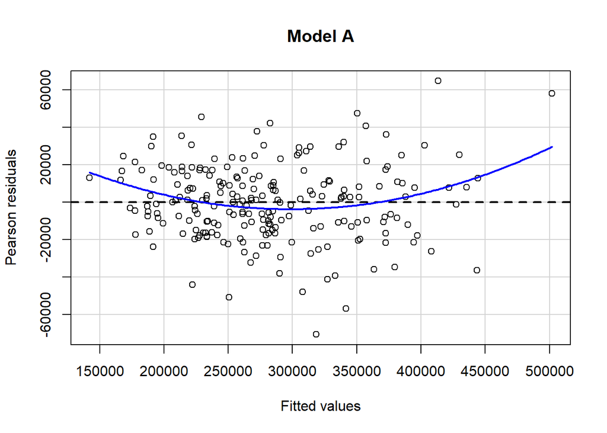

```r
residualPlot(modelA, main = "Model A")
```

Observation: The residuals versus the fitted values for Model (A) have a definite curvature indicating the model is not quite adequate.

**(e)** Finding a suitable transformation for totalprice and developing a new model

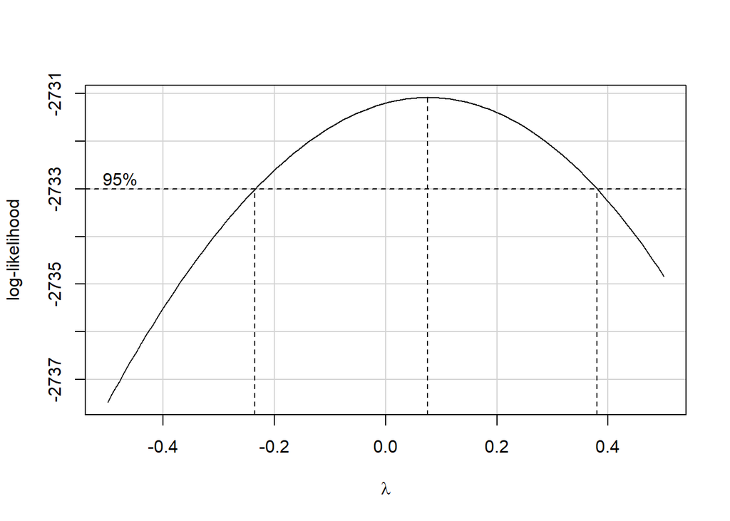

```r
boxCox(modelA, lambda = seq(-0.5, 0.5, length = 200))
```

#### Observation: A `log` transformation is suggested for the response `totalprice` in **Model (A)**.

#### **Model (E)**: Revised Log model. Data Frame `VIT2005`. “P-value-to remove” of `5`%.

```r
VIT2005$logtotalprice <- log(VIT2005$totalprice)

model.be <- lm(logtotalprice ~ ., data = VIT2005[ ,-1])
drop1(model.be, test = "F")
```

```
## Single term deletions
##
## Model:
## logtotalprice ~ area + zone + category + age + floor + rooms +
##     out + conservation + toilets + garage + elevator + streetcategory +
##     heating + storage
##                Df Sum of Sq     RSS      AIC F value    Pr(>F)
## <none>                      0.97895 -1080.46
## area            1   0.45808 1.43703  -998.78 79.0794 8.788e-16 ***
## zone           22   1.25852 2.23747  -944.25  9.8756 < 2.2e-16 ***
## category        6   0.10125 1.08020 -1071.00  2.9132  0.009938 **
## age             1   0.00061 0.97956 -1082.32  0.1045  0.746909
## floor           1   0.00185 0.98080 -1082.05  0.3191  0.572909
## rooms           1   0.00422 0.98317 -1081.52  0.7279  0.394766
## out             3   0.06721 1.04616 -1071.98  3.8675  0.010426 *
## conservation    3   0.01134 0.99029 -1083.95  0.6523  0.582546
## toilets         1   0.08460 1.06356 -1064.39 14.6057  0.000186 ***
## garage          1   0.14304 1.12199 -1052.73 24.6935 1.636e-06 ***
## elevator        1   0.14529 1.12424 -1052.29 25.0826 1.373e-06 ***
## streetcategory  3   0.03040 1.00935 -1079.79  1.7492  0.158880
## heating         3   0.04007 1.01902 -1077.71  2.3060  0.078550 .
## storage         1   0.03280 1.01175 -1075.27  5.6625  0.018445 *
## ---
## Signif. codes:  0 '***' 0.001 '**' 0.01 '*' 0.05 '.' 0.1 ' ' 1
```

Decide to drop: age

```r
model.be <- update(model.be, .~. -age)
drop1(model.be, test = "F")
```

```
## Single term deletions
##
## Model:
## logtotalprice ~ area + zone + category + floor + rooms + out +
##     conservation + toilets + garage + elevator + streetcategory +
##     heating + storage
##                Df Sum of Sq     RSS      AIC F value    Pr(>F)
## <none>                      0.97956 -1082.32
## area            1   0.46618 1.44574  -999.46 80.9051 4.535e-16 ***
## zone           22   1.26736 2.24692  -945.34  9.9977 < 2.2e-16 ***
## category        6   0.10075 1.08031 -1072.98  2.9142 0.0099017 **
## floor           1   0.00202 0.98158 -1083.87  0.3509 0.5543866
## rooms           1   0.00422 0.98378 -1083.39  0.7322 0.3933744
## out             3   0.06702 1.04658 -1073.90  3.8772 0.0102869 *
## conservation    3   0.01128 0.99084 -1085.83  0.6525 0.5824434
## toilets         1   0.08451 1.06406 -1066.28 14.6657 0.0001803 ***
## garage          1   0.14340 1.12296 -1054.54 24.8869 1.492e-06 ***
## elevator        1   0.14688 1.12643 -1053.87 25.4902 1.136e-06 ***
## streetcategory  3   0.03151 1.01107 -1081.42  1.8229 0.1448410
## heating         3   0.04185 1.02140 -1079.20  2.4207 0.0678034 .
## storage         1   0.03220 1.01175 -1077.27  5.5875 0.0192183 *
## ---
## Signif. codes:  0 '***' 0.001 '**' 0.01 '*' 0.05 '.' 0.1 ' ' 1
```

Decide to drop: conservation

```r
model.be <- update(model.be, .~. - conservation)
drop1(model.be, test = "F")
```

```
## Single term deletions
##
## Model:
## logtotalprice ~ area + zone + category + floor + rooms + out +
##     toilets + garage + elevator + streetcategory + heating +
##     storage
##                Df Sum of Sq     RSS     AIC F value    Pr(>F)
## <none>                      0.99084 -1085.8
## area            1   0.46386 1.45470 -1004.1 80.9902 3.978e-16 ***
## zone           22   1.27513 2.26596  -949.5 10.1199 < 2.2e-16 ***
## category        6   0.12795 1.11878 -1071.3  3.7233 0.0016539 **
## floor           1   0.00212 0.99295 -1087.4  0.3700 0.5437901
## rooms           1   0.00384 0.99468 -1087.0  0.6706 0.4139769
## out             3   0.07314 1.06397 -1076.3  4.2565 0.0062592 **
## toilets         1   0.08930 1.08013 -1069.0 15.5913 0.0001142 ***
## garage          1   0.15229 1.14313 -1056.7 26.5903 6.824e-07 ***
## elevator        1   0.14955 1.14039 -1057.2 26.1122 8.459e-07 ***
## streetcategory  3   0.03302 1.02385 -1084.7  1.9216 0.1278696
## heating         3   0.03941 1.03025 -1083.3  2.2939 0.0796834 .
## storage         1   0.03105 1.02189 -1081.1  5.4221 0.0210400 *
## ---
## Signif. codes:  0 '***' 0.001 '**' 0.01 '*' 0.05 '.' 0.1 ' ' 1
```

Decide to drop: floor

```r
model.be <- update(model.be, .~. - floor)
drop1(model.be, test = "F")
```

```
## Single term deletions
##
## Model:
## logtotalprice ~ area + zone + category + rooms + out + toilets +
##     garage + elevator + streetcategory + heating + storage
##                Df Sum of Sq     RSS      AIC F value    Pr(>F)
## <none>                      0.99295 -1087.36
## area            1   0.46227 1.45522 -1006.04 81.0051 3.828e-16 ***
## zone           22   1.32477 2.31772  -946.57 10.5521 < 2.2e-16 ***
## category        6   0.13186 1.12482 -1072.18  3.8512 0.0012404 **
## rooms           1   0.00390 0.99685 -1088.51  0.6826 0.4098210
## out             3   0.07320 1.06615 -1077.86  4.2757 0.0060983 **
## toilets         1   0.08971 1.08266 -1070.51 15.7202 0.0001071 ***
## garage          1   0.15125 1.14420 -1058.45 26.5036 7.058e-07 ***
## elevator        1   0.15179 1.14474 -1058.35 26.5984 6.764e-07 ***
## streetcategory  3   0.03140 1.02435 -1086.57  1.8340 0.1427479
## heating         3   0.04104 1.03400 -1084.53  2.3975 0.0697654 .
## storage         1   0.02921 1.02217 -1083.04  5.1190 0.0249012 *
## ---
## Signif. codes:  0 '***' 0.001 '**' 0.01 '*' 0.05 '.' 0.1 ' ' 1
```

Decide to drop: rooms

```r
model.be <- update(model.be, .~. - rooms)
drop1(model.be, test = "F")
```

```
## Single term deletions
##
## Model:
## logtotalprice ~ area + zone + category + out + toilets + garage +
##     elevator + streetcategory + heating + storage
##                Df Sum of Sq     RSS      AIC  F value    Pr(>F)
## <none>                      0.99685 -1088.51
## area            1   0.63037 1.62722  -983.68 110.6630 < 2.2e-16 ***
## zone           22   1.32105 2.31790  -948.56  10.5415 < 2.2e-16 ***
## category        6   0.12882 1.12567 -1074.01   3.7690  0.001487 **
## out             3   0.07696 1.07381 -1078.30   4.5036  0.004526 **
## toilets         1   0.09245 1.08930 -1071.17  16.2297 8.353e-05 ***
## garage          1   0.15205 1.14890 -1059.56  26.6921 6.452e-07 ***
## elevator        1   0.15775 1.15460 -1058.48  27.6935 4.121e-07 ***
## streetcategory  3   0.03042 1.02727 -1087.95   1.7802  0.152691
## heating         3   0.04262 1.03947 -1085.38   2.4940  0.061618 .
## storage         1   0.02789 1.02474 -1084.49   4.8962  0.028210 *
## ---
## Signif. codes:  0 '***' 0.001 '**' 0.01 '*' 0.05 '.' 0.1 ' ' 1
```

Decide to drop: streetcategory

```r
model.be <- update(model.be, .~. - streetcategory)
drop1(model.be, test = "F")
```

```
## Single term deletions
##
## Model:
## logtotalprice ~ area + zone + category + out + toilets + garage +
##     elevator + heating + storage
##          Df Sum of Sq    RSS      AIC  F value    Pr(>F)
## <none>                1.0273 -1087.95
## area      1   0.60883 1.6361  -988.50 105.4941 < 2.2e-16 ***
## zone     22   1.32896 2.3562  -950.98  10.4671 < 2.2e-16 ***
## category  6   0.13418 1.1615 -1073.19   3.8749  0.001164 **
## out       3   0.07692 1.1042 -1078.21   4.4426  0.004885 **
## toilets   1   0.09796 1.1252 -1070.10  16.9737 5.799e-05 ***
## garage    1   0.15375 1.1810 -1059.55  26.6413 6.501e-07 ***
## elevator  1   0.15048 1.1778 -1060.15  26.0751 8.391e-07 ***
## heating   3   0.04847 1.0757 -1083.90   2.7994  0.041510 *
## storage   1   0.04202 1.0693 -1081.21   7.2813  0.007638 **
## ---
## Signif. codes:  0 '***' 0.001 '**' 0.01 '*' 0.05 '.' 0.1 ' ' 1
```

```r
formula(model.be)
```

```
## logtotalprice ~ area + zone + category + out + toilets + garage +
##     elevator + heating + storage
```

```r
modelE <- lm(formula(model.be), data = VIT2005)
```

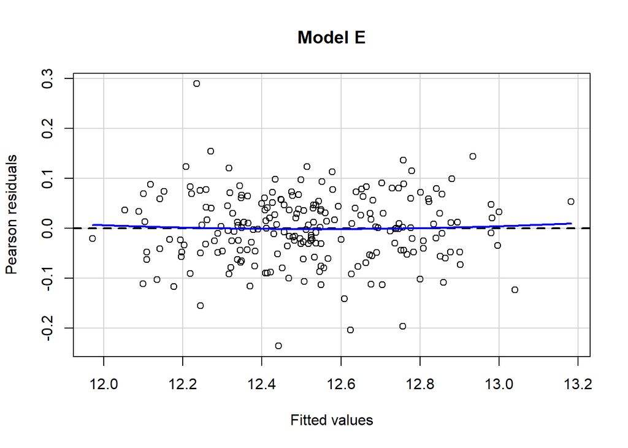

```r
residualPlot(modelE, main = "Model E")
```